# Sampling problems with latent variables: No vehicles in the park

Author

Andrew Gelman and Aki Vehtari

Published

2025-09-16

Modified

2026-06-15

This notebook includes the code for Bayesian Workflow book Chapter 29 *Sampling problems with latent variables: No vehicles in the park*.

# 1 Introduction

It can be hard to sample from a posterior of even a simple multilevel model. We demonstrate with an example that began with a post from (Luu 2024), which pointed to an online quiz from (Turner 2024) adapted from (Hart 1958) (see also Schlag (1999))

**Load packages**

````r
library(rprojroot)
root <- has_file(".Bayesian-Workflow-root")$make_fix_file()
library(arm)
library(posterior)
options(posterior.num_args = list(digits = 2), digits = 2, width = 90)
library(lme4)
library(cmdstanr)
options(mc.cores = 4)
# CmdStanR output directory makes Quarto cache to work
dir.create(root("park_rule", "stan_output"), showWarnings = FALSE)
options(cmdstanr_output_dir = root("park_rule", "stan_output"))
library(ggplot2)
library(bayesplot)
theme_set(bayesplot::theme_default(base_family = "sans", base_size = 14))
library(ggdist)
library(patchwork)
library(tictoc)
mytoc <- \() {
  toc(func.toc = \(tic, toc, msg) {
    sprintf("%s took %s sec", msg, as.character(signif(toc - tic, 2)))
  })}

print_stan_code <- function(code) {
  if (isTRUE(getOption("knitr.in.progress")) &
        identical(knitr::opts_current$get("results"), "asis")) {
    # In render: emit as-is so Pandoc/Quarto does syntax highlighting
    block <- paste0("```stan", "\n", paste(code, collapse = "\n"), "\n", "```")
    knitr::asis_output(block)
  } else {
    writeLines(code)
  }
}
````

# 2 Data

Data has 51953 responses from 2409 people giving yes/no answers to 27 questions about no vehicles in the park rule. Each row of the data file includes indexes for the respondent and the question, indicators if the person described in the survey question has a male-sounding or white-sounding name, and the outcome: 1 for the response, `Yes, this violates the rule'' and 0 for the response,`No, this does not violate the rule.’’

```r
park <- read.csv(root("park_rule", "data", "park.csv"))
N <- nrow(park)
respondents <- sort(unique(park$submission_id))
J <- length(respondents)
respondent <- rep(NA, N)
for (j in 1:J) {
  respondent[park$submission_id == respondents[j]] <- j
}
items <- sort(unique(park$question_id))
K <- length(items)
item <- park$question_id
y <- park$answer
n_responses <- rep(NA, J)
for (j in 1:J) {
  n_responses[j] <- sum(respondent == j)
}
male_name <- park$male
white_name <- park$white
```

add number of answered questions as a predictor

```r
n_responses_full <- n_responses[respondent]
```

# 3 lme4 model

`lme4` performs fast fitting of simple multilevel models using approximate marginal maximum likelihood for the variance parameters. We start with lme4 for quick analysis to get some insights to the data.

```r
data_park <- data.frame(y,
                        respondent,
                        item,
                        male_name,
                        white_name,
                        n_responses_full)
tic("lme4 fit 1")
fit_lme4 <- glmer(
  y ~ (1 | item) + (1 | respondent) + male_name + white_name + n_responses_full,
  family = binomial(link = "logit"),
  data = data_park
)
mytoc()
```

```
lme4 fit 1 took 14 sec
```

```r
display(fit_lme4)
```

```
glmer(formula = y ~ (1 | item) + (1 | respondent) + male_name +
    white_name + n_responses_full, data = data_park, family = binomial(link = "logit"))
                 coef.est coef.se
(Intercept)      -1.50     0.47
male_name         0.07     0.03
white_name        0.08     0.03
n_responses_full -0.03     0.01

Error terms:
 Groups     Name        Std.Dev.
 respondent (Intercept) 1.92
 item       (Intercept) 2.31
 Residual               1.00
---
number of obs: 51953, groups: respondent, 2409; item, 27
AIC = 32517.4, DIC = 19437
deviance = 25971.2
```

## 3.1 Refit the model

Code the last predictor in terms of the number of items skipped so that zero is a reasonable baseline.

```r
n_skipped <- K - n_responses
n_skipped_full <- n_skipped[respondent]
data_park <- data.frame(y,
                        respondent,
                        item,
                        male_name,
                        white_name,
                        n_skipped_full)

tic("lme4 fit 2")
fit_lme4 <- glmer(
  y ~ (1 | item) + (1 | respondent) + male_name + white_name + n_skipped_full,
  family = binomial(link = "logit"),
  data = data_park
)
mytoc()
```

```
lme4 fit 2 took 14 sec
```

```r
display(fit_lme4)
```

```
glmer(formula = y ~ (1 | item) + (1 | respondent) + male_name +
    white_name + n_skipped_full, data = data_park, family = binomial(link = "logit"))
               coef.est coef.se
(Intercept)    -2.42     0.45
male_name       0.07     0.03
white_name      0.08     0.03
n_skipped_full  0.03     0.01

Error terms:
 Groups     Name        Std.Dev.
 respondent (Intercept) 1.92
 item       (Intercept) 2.31
 Residual               1.00
---
number of obs: 51953, groups: respondent, 2409; item, 27
AIC = 32517.4, DIC = 19437
deviance = 25971.2
```

```r
mean(y)
```

```
[1] 0.24
```

```r
mean(y[male_name == 0 & white_name == 0 & n_skipped_full == 0])
```

```
[1] 0.22
```

```r
sum(male_name == 0 & white_name == 0 & n_skipped_full == 0)
```

```
[1] 10748
```

```r
invlogit(-2.42 + 0.07*mean(male_name) + 0.08*mean(white_name) + 0.03*mean(n_skipped_full))
```

```
[1] 0.093
```

```r
mean(predict(fit_lme4, type = "response"))
```

```
[1] 0.24
```

## 3.2 Simulate data and refit

Check with simulated data that inference works.

```r
set.seed(123)
a_respondent_sim <- rnorm(J, 0, sqrt(VarCorr(fit_lme4)$respondent))
a_item_sim <- rnorm(K, 0, sqrt(VarCorr(fit_lme4)$item))
b_sim <- fixef(fit_lme4)
X <- cbind(1, male_name, white_name, n_skipped_full)
p_sim <- invlogit(a_respondent_sim[respondent] + a_item_sim[item] + X %*% b_sim)
y_sim <- rbinom(N, 1, p_sim)
data_sim <- data.frame(data_park, y_sim)

tic("lme4 fit sim")
fit_lme4_sim <- glmer(
  y_sim ~ (1 | item) + (1 | respondent) + male_name + white_name + n_responses_full,
  family = binomial(link = "logit"),
  data = data_sim
)
mytoc()
```

```
lme4 fit sim took 15 sec
```

```r
display(fit_lme4_sim)
```

```
glmer(formula = y_sim ~ (1 | item) + (1 | respondent) + male_name +
    white_name + n_responses_full, data = data_sim, family = binomial(link = "logit"))
                 coef.est coef.se
(Intercept)      -1.88     0.53
male_name         0.06     0.03
white_name        0.11     0.03
n_responses_full -0.04     0.01

Error terms:
 Groups     Name        Std.Dev.
 respondent (Intercept) 1.87
 item       (Intercept) 2.65
 Residual               1.00
---
number of obs: 51953, groups: respondent, 2409; item, 27
AIC = 29244.3, DIC = 16807
deviance = 23019.5
```

```r
a_item_hat <- ranef(fit_lme4)$item
print(a_item_hat, digits = 1)
```

```
   (Intercept)
1         7.61
2         3.01
3        -0.74
4        -1.02
5         1.15
6        -0.97
7        -0.51
8         1.99
9         3.23
10        1.34
11       -1.25
12       -3.17
13        0.49
14       -1.24
15       -0.59
16        0.61
17       -2.78
18       -1.59
19        0.02
20       -2.79
21        1.04
22        0.30
23       -0.05
24       -1.49
25       -0.04
26       -0.50
27        2.01
```

## 3.3 Plots

```r
wordings <- read.csv(root("park_rule", "data", "park.txt"), header = FALSE)$V2
wordings <- substr(wordings, 2, nchar(wordings) - 1)
a_item_hat <- unlist(a_item_hat)
names(a_item_hat) <- wordings
print(sort(a_item_hat), digits=1)
```

```
              kite     paper_airplane                iss             toycar
             -3.17              -2.79              -2.78              -1.59
        ice_skates            toyboat          parachute              plane
             -1.49              -1.25              -1.24              -1.02
         surfboard             skates skateboard_carried         wheelchair
             -0.97              -0.74              -0.59              -0.51
          stroller            travois               sled              rccar
             -0.50              -0.05              -0.04               0.02
             horse         quadcopter         skateboard         wagon_kids
              0.30               0.49               0.61               1.04
             wagon            rowboat               bike           memorial
              1.15               1.34               1.99               2.01
         ambulance             police                car
              3.01               3.23               7.61
```

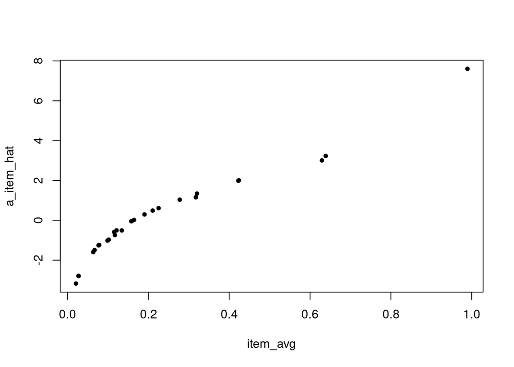

Figure 1

```r
item_avg <- rep(NA, K)
for (k in 1:K) {
  item_avg[k] <- mean(y[item==k])
}
plot(item_avg, a_item_hat, pch=20)
```

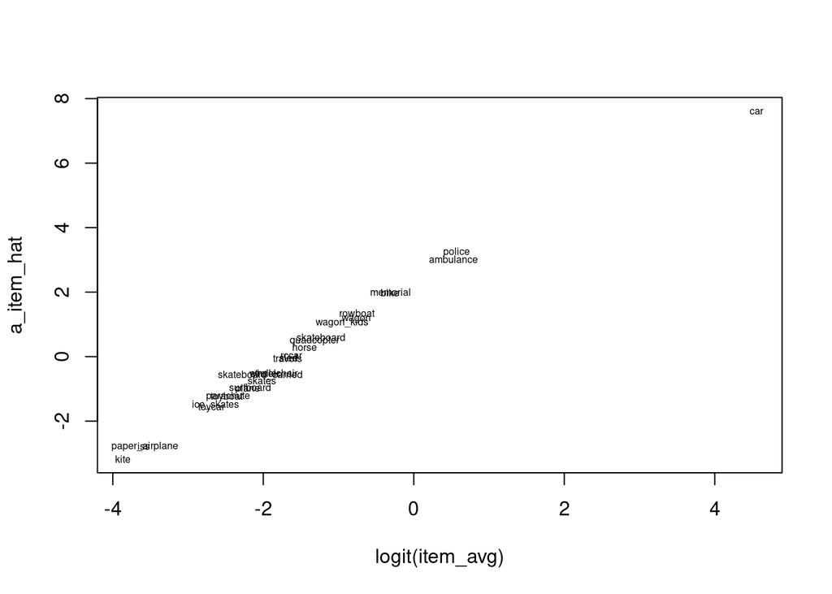

Figure 2

```r
plot(logit(item_avg), a_item_hat, type = "n")
text(logit(item_avg), a_item_hat, names(a_item_hat), cex = .5)
```

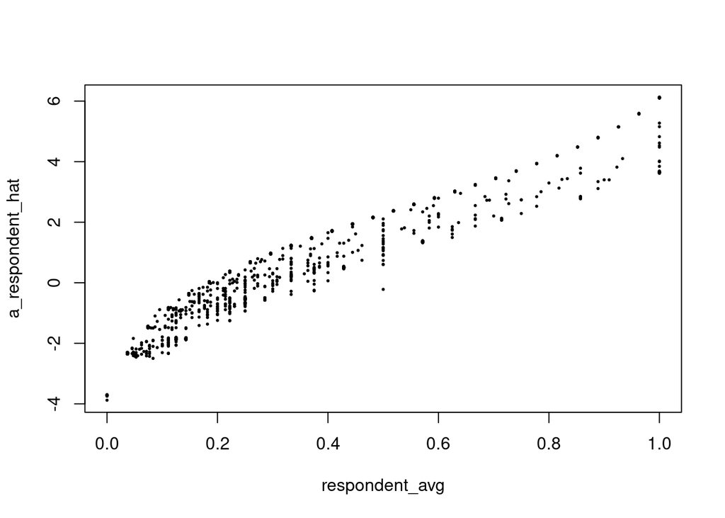

Figure 3

```r
a_respondent_hat <- unlist(ranef(fit_lme4)$respondent)
respondent_avg <- rep(NA, J)
for (j in 1:J) {
  respondent_avg[j] <- mean(y[respondent == j])
}
plot(respondent_avg, a_respondent_hat, pch = 20, cex = .4)
```

# 4 Stan models

In general we prefer full Bayesian inference, even if it may take more time.

## 4.1 Stan data

CmdStanR needs the data in list format.

```r
X <- cbind(male_name, white_name, n_skipped_full)
stan_data <- list(
  N = N,
  J = J,
  K = K,
  L = ncol(X),
  y = y,
  respondent = respondent,
  item = item,
  X = X
)
```

## 4.2 Hierarchical logistic regression with non-centered parameterization

Hierarchical models of often benefit from non-centered parameterization, so we start with that. We use `<multiplier=...>` declaration to implement the non-centered parameterization. In the model block, we use `bernoulli_logit_glm()`, which is more efficient than `bernoulli_logit()` and can be used when the latent model can be presented as a linear model. We use weak priors for the coefficients and varying effect population scales.

```r
park_1 <- cmdstan_model(root("park_rule", "park_1.stan"))
```

```r
print_stan_code(park_1$code())
```

```stan
data {
  int<lower=0> N, J, K, L;
  array[N] int<lower=0, upper=1> y;
  array[N] int<lower=1, upper=J> respondent;
  array[N] int<lower=1, upper=K> item;
  matrix[N, L] X;
}
parameters {
  real a;
  vector[L] b;
  real<lower=0> sigma_respondent, sigma_item;
  vector<multiplier=sigma_respondent>[J] a_respondent;
  vector<multiplier=sigma_item>[K] a_item;
}
model {
  a_respondent ~ normal(0, sigma_respondent);
  a_item ~ normal(0, sigma_item);
  b ~ normal(0, 1);
  {sigma_respondent, sigma_item} ~ normal(0, 3);
  y ~ bernoulli_logit_glm(X, a + a_respondent[respondent] + a_item[item], b);
}
```

```r
tic("Stan sampling model 1")
fit_1 <- park_1$sample(data = stan_data, init = 0.1,
                       iter_warmup = 200, iter_sampling = 200)
```

```r
mytoc()
```

```
Stan sampling model 1 took 290 sec
```

```r
print(fit_1)
```

```
         variable     mean   median    sd   mad       q5      q95 rhat ess_bulk ess_tail
 lp__             -1.5e+04 -1.5e+04 46.96 45.25 -1.5e+04 -1.5e+04 1.05       93      252
 a                -2.4e+00 -2.4e+00  0.46  0.46 -3.1e+00 -1.5e+00 1.29       11       30
 b[1]              7.0e-02  7.0e-02  0.03  0.03  2.0e-02  1.2e-01 1.00     1608      707
 b[2]              8.0e-02  8.0e-02  0.03  0.03  3.0e-02  1.4e-01 1.01     1874      613
 b[3]              3.0e-02  3.0e-02  0.01  0.01  2.0e-02  4.0e-02 1.01      336      425
 sigma_respondent  1.9e+00  1.9e+00  0.04  0.04  1.9e+00  2.0e+00 1.02      239      529
 sigma_item        2.4e+00  2.4e+00  0.37  0.34  1.9e+00  3.1e+00 1.02      127      191
 a_respondent[1]  -2.9e-01 -3.1e-01  1.69  1.83 -3.1e+00  2.4e+00 1.01     2174      621
 a_respondent[2]  -4.0e-01 -3.9e-01  0.70  0.69 -1.7e+00  6.8e-01 1.02     1145      458
 a_respondent[3]   1.4e+00  1.4e+00  0.48  0.49  5.9e-01  2.1e+00 1.00     1436      522

 # showing 10 of 2443 rows (change via 'max_rows' argument or 'cmdstanr_max_rows' option)
```

We see some suspiciously high $\widehat{R}$ values and low ESSs. We didn’t get divergence warnings, so the reason is unlikely to be a funnel shaped posterior. We also didn’t get maximum treedepth exceedences warnings, so the there is no obvious high correlations. We can further examine the sampler diagnostics:

```r
fit_1$sampler_diagnostics() |> as_draws_rvars()
```

```
# A draws_rvars: 200 iterations, 4 chains, and 6 variables
$treedepth__: rvar<200,4>[1] mean ± sd:
[1] 6.8 ± 0.4

$divergent__: rvar<200,4>[1] mean ± sd:
[1] 0 ± 0

$energy__: rvar<200,4>[1] mean ± sd:
[1] 16306 ± 57

$accept_stat__: rvar<200,4>[1] mean ± sd:
[1] 0.93 ± 0.085

$stepsize__: rvar<200,4>[1] mean ± sd:
[1] 0.044 ± 0.007

$n_leapfrog__: rvar<200,4>[1] mean ± sd:
[1] 118 ± 22
```

We are specifically interested in how efficient each Hamiltonian Monte Carlo iteration is. This can be measured by the number of leapfrog steps `n_leapfrog__`, which is close to the number of log density and gradient evaluations. Instead of examining `n_leapfrog__` directly, it is common to examine `treedepth__` as it scales logarithmically with respect to `n_leapfrog__`. More specifically, $\text{treedepth\_\_}=\log_2(\text{treedepth\_\_}+1)$. Average `treedepth__` is about 7 which is not high for hierarchical model posteriors, and the variation measured by standard deviation is low which indicates that the posterior curvature is not highly varying and thus there is no strong funnel shape. As ESSs are low for the parameter `a`, we check the trace plot.

```r
draws_1 <- fit_1$draws(format = "df")
```

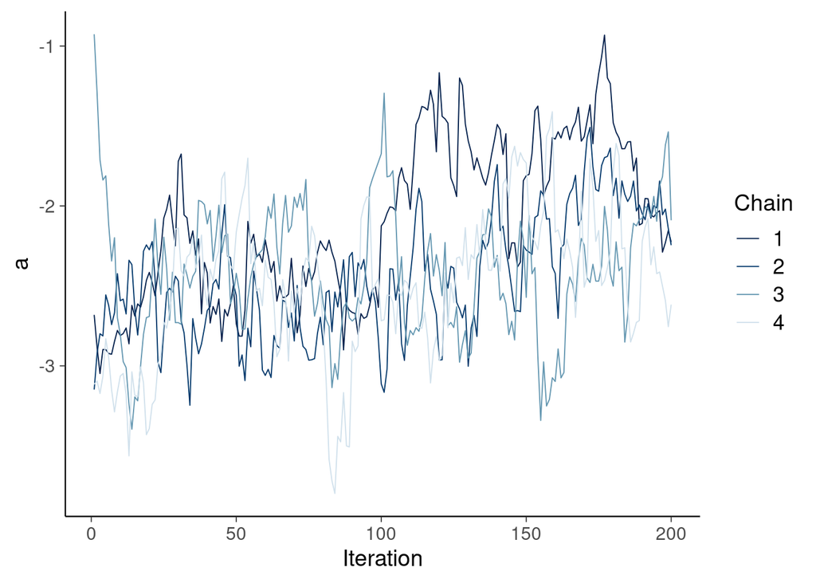

Figure 4

```r
draws_1 |>
  mcmc_trace(pars = "a") +
  labs(x = "Iteration")
```

There is clearly high auto-correlation. As we have 51953 observations, we would expect the posterior for `a` to be narrow, but now the posterior standard deviation is 0.46.

Examining the model code, we see

```stan
  y ~ bernoulli_logit_glm(X, a + a_respondent[respondent] + a_item[item], b);
```

and remember the discussion in Section 12.3 about parameters with similar roles and identifiability. Here all `a`, `a_respondent` and `a_item` influence the total intercept. If value of `a` increases, the total intercept stays the same if values of `a_respondent` and `a_item` get lower at the same time. These parameters are not well identified alone.

Let’s check the diagnostics for `a_respondent` and `a_item`, too.

```r
draws_1 |>
  subset_draws(variable = "a_respondent") |>
  summarize_draws()
```

```
# A tibble: 2,409 × 10
   variable          mean median    sd   mad    q5   q95  rhat ess_bulk ess_tail
   <chr>            <dbl>  <dbl> <dbl> <dbl> <dbl> <dbl> <dbl>    <dbl>    <dbl>
 1 a_respondent[1]  -0.29  -0.31  1.69  1.83 -3.09  2.37  1.01  2174.04   621.43
 2 a_respondent[2]  -0.40  -0.39  0.70  0.69 -1.67  0.68  1.02  1145.63   458.25
 3 a_respondent[3]   1.35   1.36  0.48  0.49  0.59  2.13  1.00  1436.17   522.30
 4 a_respondent[4]  -0.58  -0.51  1.18  1.17 -2.66  1.28  1.00  1641.24   561.18
 5 a_respondent[5]  -0.55  -0.47  1.12  1.17 -2.45  1.20  1.01  1586.11   710.98
 6 a_respondent[6]  -0.91  -0.86  0.76  0.79 -2.17  0.29  1.00  1504.70   515.67
 7 a_respondent[7]  -2.63  -2.56  1.09  1.16 -4.56 -0.99  1.01  1175.91   517.02
 8 a_respondent[8]   0.76   0.76  0.57  0.58 -0.17  1.67  1.00  1087.90   464.82
 9 a_respondent[9]  -2.57  -2.49  1.03  1.04 -4.42 -1.00  1.01   816.80   446.94
10 a_respondent[10]  1.99   1.99  0.66  0.62  0.83  3.05  1.01  1327.17   554.86
# ℹ 2,399 more rows
```

```r
draws_1 |>
  subset_draws(variable = "a_item") |>
  summarize_draws()
```

```
# A tibble: 27 × 10
   variable    mean median    sd   mad    q5   q95  rhat ess_bulk ess_tail
   <chr>      <dbl>  <dbl> <dbl> <dbl> <dbl> <dbl> <dbl>    <dbl>    <dbl>
 1 a_item[1]   8.21   8.23  0.52  0.55  7.31  9.04  1.21    14.32    56.19
 2 a_item[2]   3.00   3.03  0.47  0.44  2.17  3.76  1.27    12.04    36.25
 3 a_item[3]  -1.04  -1.00  0.47  0.46 -1.88 -0.30  1.27    12.22    52.87
 4 a_item[4]  -1.34  -1.30  0.47  0.46 -2.16 -0.57  1.26    12.31    46.47
 5 a_item[5]   0.96   1.00  0.47  0.45  0.12  1.69  1.28    11.76    33.13
 6 a_item[6]  -1.29  -1.26  0.47  0.46 -2.12 -0.56  1.25    12.64    28.31
 7 a_item[7]  -0.80  -0.75  0.47  0.46 -1.62 -0.06  1.26    12.19    29.59
 8 a_item[8]   1.84   1.88  0.47  0.46  1.04  2.59  1.27    11.96    24.67
 9 a_item[9]   3.20   3.24  0.47  0.45  2.39  3.95  1.28    11.72    29.28
10 a_item[10]  1.15   1.19  0.47  0.46  0.32  1.88  1.27    11.96    43.40
# ℹ 17 more rows
```

The ESSs for `a_respondent` are high and ESSs for `a_item` are low. As each `a_respondent` depends on a smaller number of observations, the related uncertainty swamps the autocorrelation due to the dependency.

We can examine the scatter plot of `a` and sum of `a_item` to see the strong correlation.

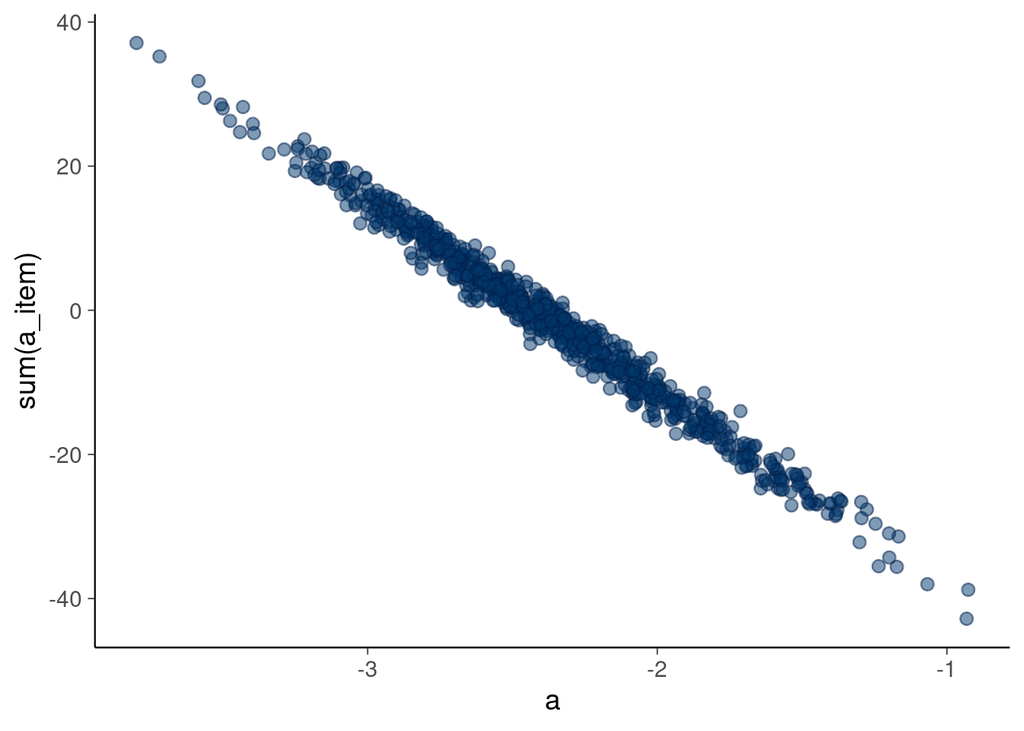

Figure 5

```r
draws_rvars(a = as_draws_rvars(draws_1)$a,
            sum_a_item = as_draws_rvars(draws_1)$a_item |> rvar_sum()) |>
  mcmc_scatter(alpha = 0.5) +
  labs(y = "sum(a_item)")
```

## 4.3 Hierarchical logistic regression with sum-to-zero parameterization

We can remove the identifiability problem by constraining `a_respondent` and `a_item` to have sum zero. This can be easily achieved in Stan with `sum_to_zero_vector` data type. In addition of potentially improving sampling speed, sum-to-zero constraint reducing posterior dependencies improves also interpretability of the marginal posteriors of the parameters. As `sum_to_zero_vector` data type does not allow `multiplier`, we need to change how we implement the non-centered parameterization.

```r
park_2 <- cmdstan_model(root("park_rule", "park_2.stan"))
```

```r
print_stan_code(park_2$code())
```

```stan
data {
  int<lower=0> N, J, K, L;
  array[N] int<lower=0, upper=1> y;
  array[N] int<lower=1, upper=J> respondent;
  array[N] int<lower=1, upper=K> item;
  matrix[N, L] X;
}
parameters {
  real a;
  vector[L] b;
  real<lower=0> sigma_respondent, sigma_item;
  sum_to_zero_vector[J] z_respondent;
  sum_to_zero_vector[K] z_item;
}
transformed parameters {
  vector[J] a_respondent = z_respondent * sigma_respondent;
  vector[K] a_item = z_item * sigma_item;
}
model {
  z_respondent ~ std_normal();
  z_item ~ std_normal();
  b ~ normal(0, 1);
  {sigma_respondent, sigma_item} ~ normal(0, 3);
  y ~ bernoulli_logit_glm(X, a + a_respondent[respondent] + a_item[item], b);
}
```

```r
tic("Stan sampling model 2")
fit_2 <- park_2$sample(data = stan_data, init = 0.1,
                       iter_warmup = 200, iter_sampling = 200)
```

```r
mytoc()
```

```
Stan sampling model 2 took 280 sec
```

```r
draws_2 <- fit_2$draws(format = "df")
print(fit_2)
```

```
         variable     mean   median    sd   mad       q5      q95 rhat ess_bulk ess_tail
 lp__             -1.5e+04 -1.5e+04 50.97 48.72 -1.5e+04 -1.5e+04 1.02      165      222
 a                -2.4e+00 -2.4e+00  0.04  0.04 -2.5e+00 -2.4e+00 1.00      584      747
 b[1]              7.0e-02  7.0e-02  0.03  0.03  2.0e-02  1.2e-01 1.01     1570      607
 b[2]              8.0e-02  8.0e-02  0.03  0.04  3.0e-02  1.3e-01 1.00     2120      674
 b[3]              3.0e-02  3.0e-02  0.01  0.01  3.0e-02  4.0e-02 1.01      337      489
 sigma_respondent  1.9e+00  1.9e+00  0.04  0.04  1.9e+00  2.0e+00 1.01      277      447
 sigma_item        2.5e+00  2.4e+00  0.33  0.31  2.0e+00  3.1e+00 1.03      117      221
 z_respondent[1]  -1.7e-01 -1.2e-01  0.88  0.85 -1.7e+00  1.2e+00 1.00      590      490
 z_respondent[2]  -2.2e-01 -2.0e-01  0.36  0.38 -8.6e-01  3.6e-01 1.01      613      594
 z_respondent[3]   7.0e-01  7.1e-01  0.26  0.24  2.8e-01  1.1e+00 1.01      937      580

 # showing 10 of 4879 rows (change via 'max_rows' argument or 'cmdstanr_max_rows' option)
```

Now $\widehat{R}$ and ESSs indicate problems with `sigma_item`. Examining the sampler diagnostics, shows that `treedepth` is lower, indicating smaller posterior correlations, and still with low standard deviation, indicating that curvature is not highly varying.

```r
fit_2$sampler_diagnostics() |> as_draws_rvars()
```

```
# A draws_rvars: 200 iterations, 4 chains, and 6 variables
$treedepth__: rvar<200,4>[1] mean ± sd:
[1] 6.5 ± 0.5

$divergent__: rvar<200,4>[1] mean ± sd:
[1] 0 ± 0

$energy__: rvar<200,4>[1] mean ± sd:
[1] 16304 ± 63

$accept_stat__: rvar<200,4>[1] mean ± sd:
[1] 0.93 ± 0.083

$stepsize__: rvar<200,4>[1] mean ± sd:
[1] 0.06 ± 0.017

$n_leapfrog__: rvar<200,4>[1] mean ± sd:
[1] 95 ± 32
```

We examine the convergence diagnostics for `a_item`.

```r
draws_2 |>
  subset_draws(variable = "a_item") |>
  summarize_draws()
```

```
# A tibble: 27 × 10
   variable    mean median    sd   mad    q5   q95  rhat ess_bulk ess_tail
   <chr>      <dbl>  <dbl> <dbl> <dbl> <dbl> <dbl> <dbl>    <dbl>    <dbl>
 1 a_item[1]   8.27   8.27  0.23  0.22  7.91  8.67  1.00   770.25   663.37
 2 a_item[2]   3.06   3.06  0.06  0.06  2.97  3.15  1.00   798.98   760.88
 3 a_item[3]  -0.98  -0.98  0.08  0.07 -1.11 -0.85  1.00   786.48   701.58
 4 a_item[4]  -1.27  -1.27  0.09  0.09 -1.41 -1.13  1.00   789.87   798.24
 5 a_item[5]   1.02   1.02  0.06  0.06  0.93  1.11  1.00   815.75   751.34
 6 a_item[6]  -1.22  -1.21  0.09  0.09 -1.37 -1.08  1.00   994.48   701.54
 7 a_item[7]  -0.74  -0.74  0.08  0.08 -0.88 -0.61  1.01   998.69   447.51
 8 a_item[8]   1.91   1.91  0.07  0.07  1.81  2.03  1.01  1029.50   627.94
 9 a_item[9]   3.27   3.27  0.07  0.07  3.16  3.38  1.00   791.59   762.84
10 a_item[10]  1.22   1.23  0.06  0.07  1.12  1.33  1.00  2089.46   637.61
# ℹ 17 more rows
```

The usual way to investigate funnels in hierarchical models, is to look at the scatter plot of one of the variables and corresponding prior scale. We examine `a_item` and `sigma_item`. Instead of showing plot for all variables in vector `a_item`, we show here the scatter plot for `a_item[1]` and `sigma_item´.

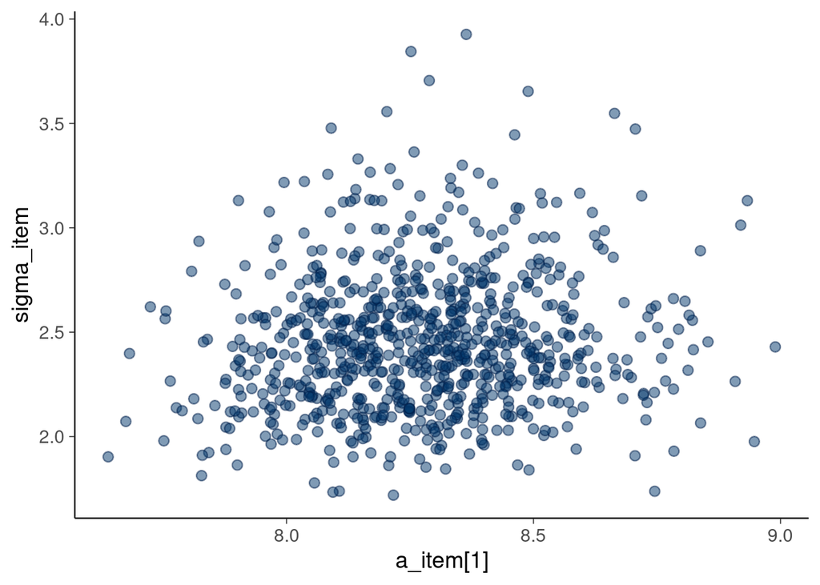

Figure 6

```r
draws_2 |>
  subset_draws(variable = c("a_item[1]","sigma_item")) |>
  mcmc_scatter(alpha = 0.5)
```

There is no indication of funnel. This is hiding the issue, as the sampling was actually done using parameters `z_respondent` and `z_item`!

```stan
  sum_to_zero_vector[J] z_respondent;
  sum_to_zero_vector[K] z_item;
```

Thus, we should investigate the sampling performance for `z_item`:

```r
draws_2 |>
  subset_draws(variable = "z_item") |>
  summarize_draws()
```

```
# A tibble: 27 × 10
   variable    mean median    sd   mad    q5   q95  rhat ess_bulk ess_tail
   <chr>      <dbl>  <dbl> <dbl> <dbl> <dbl> <dbl> <dbl>    <dbl>    <dbl>
 1 z_item[1]   3.43   3.43  0.44  0.44  2.71  4.15  1.03   128.65   218.10
 2 z_item[2]   1.27   1.27  0.17  0.16  0.98  1.54  1.03   122.21   287.14
 3 z_item[3]  -0.41  -0.40  0.06  0.06 -0.51 -0.31  1.02   162.14   355.05
 4 z_item[4]  -0.53  -0.52  0.08  0.07 -0.65 -0.41  1.02   150.34   395.81
 5 z_item[5]   0.42   0.42  0.06  0.06  0.33  0.53  1.03   145.52   229.88
 6 z_item[6]  -0.50  -0.50  0.07  0.08 -0.63 -0.39  1.02   146.13   369.87
 7 z_item[7]  -0.31  -0.30  0.05  0.05 -0.39 -0.23  1.01   206.06   392.34
 8 z_item[8]   0.79   0.79  0.11  0.10  0.62  0.96  1.03   141.23   306.76
 9 z_item[9]   1.35   1.35  0.17  0.17  1.06  1.64  1.02   118.12   268.83
10 z_item[10]  0.51   0.50  0.07  0.07  0.39  0.63  1.02   149.10   312.45
# ℹ 17 more rows
```

Now $\widehat{R}$ and ESSs indicate problems with `z_item`. We examine the scatter plot for `z_item[1]` and `sigma_item`:

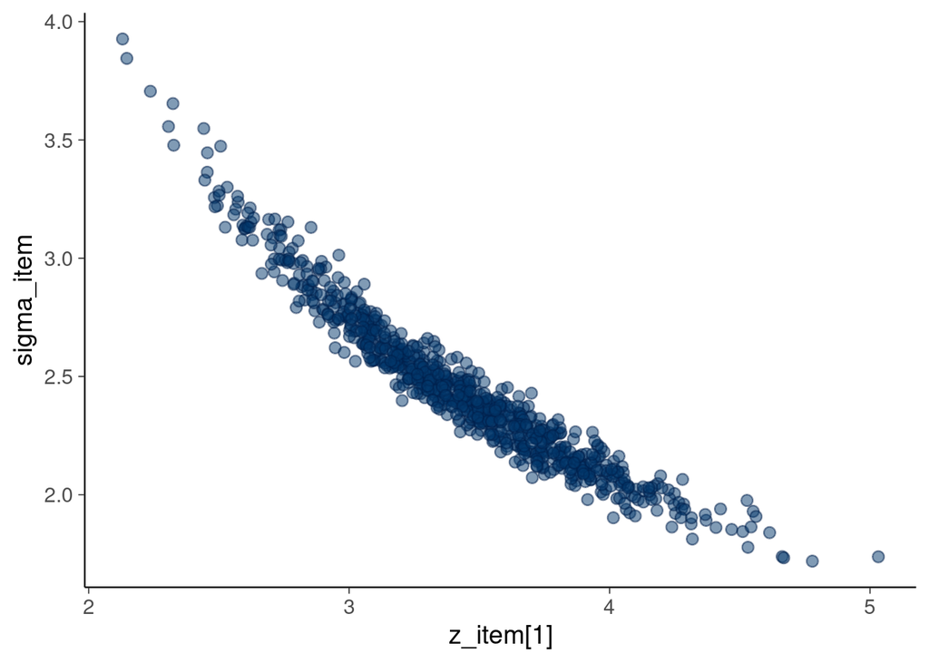

Figure 7

```r
draws_2 |>
  subset_draws(variable = c("z_item[1]","sigma_item")) |>
  mcmc_scatter(alpha = 0.5)
```

There is a strong correlation. There is also slight banana shape, but as `sigma_item` is constrained to be positive, the sampling is done in log space, and we should use that also for the scatter plot.

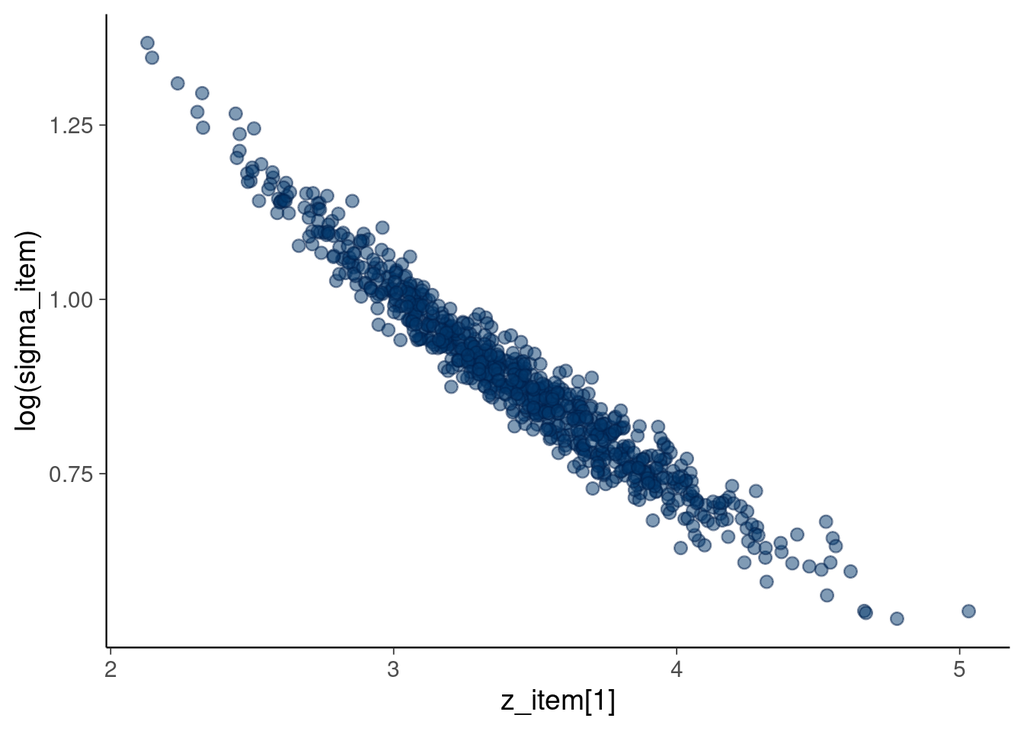

Figure 8

```r
draws_2 |>
  subset_draws(variable = c("z_item[1]","sigma_item")) |>
  mcmc_scatter(transformations = list(sigma_item=log), alpha = 0.5) +
  labs(y = "log(sigma_item)")
```

The banana shape is weaker, and we have mostly linear dependency which matches what inferred from the diagnostic values.

When non-centered parameterization is used, but the likelihood contribution is strong, we get strong dependency between the latent value `z` and `sigma`. In this case, we have a large number of observations per each item, and the centered parameterization is likely to be a better choice.

In our first model, the non-centered parameterization was implemented using vector data type with `<multiplier=...>`, which hides the latent parameter, and it is easier to miss how to detect the problem. With the explicit latent parameterization `z_item`, the issue was easier to detect.

We switch to using the centered parameterization for both `a_respondent` and `a_item`. We could still use non-centered for `a_respondent`, but further experiments not shown here, indicate that there is not much difference between the parameterizations for `a_respondent` and thus we use the simpler form.

```r
park_3 <- cmdstan_model(root("park_rule", "park_3.stan"))
```

```r
print_stan_code(park_3$code())
```

```stan
data {
  int<lower=0> N, J, K, L;
  array[N] int<lower=0, upper=1> y;
  array[N] int<lower=1, upper=J> respondent;
  array[N] int<lower=1, upper=K> item;
  matrix[N, L] X;
}
parameters {
  real a;
  vector[L] b;
  real<lower=0> sigma_respondent, sigma_item;
  sum_to_zero_vector[J] a_respondent;
  sum_to_zero_vector[K] a_item;
}
model {
  a_respondent ~ normal(0, sigma_respondent);
  a_item ~ normal(0, sigma_item);
  b ~ normal(0, 1);
  {sigma_respondent, sigma_item} ~ normal(0, 3);
  y ~ bernoulli_logit_glm(X, a + a_respondent[respondent] + a_item[item], b);
}
```

```r
tic("Stan sampling model 3")
fit_3 <- park_3$sample(data = stan_data, init = 0.1,
                       iter_warmup = 200, iter_sampling = 200)
```

```r
mytoc()
```

```
Stan sampling model 3 took 270 sec
```

```r
draws_3 <- fit_3$draws(format = "df")
print(fit_3)
```

```
         variable     mean   median    sd   mad       q5      q95 rhat ess_bulk ess_tail
 lp__             -1.7e+04 -1.7e+04 40.57 39.74 -1.7e+04 -1.7e+04 1.01      292      423
 a                -2.4e+00 -2.4e+00  0.04  0.04 -2.5e+00 -2.4e+00 1.00      437      370
 b[1]              7.0e-02  7.0e-02  0.03  0.03  2.0e-02  1.2e-01 1.00     1371      654
 b[2]              8.0e-02  8.0e-02  0.03  0.03  3.0e-02  1.3e-01 1.01     1948      772
 b[3]              3.0e-02  3.0e-02  0.01  0.01  2.0e-02  4.0e-02 1.01      336      421
 sigma_respondent  1.9e+00  1.9e+00  0.04  0.04  1.9e+00  2.0e+00 1.00      448      691
 sigma_item        2.4e+00  2.4e+00  0.31  0.31  1.9e+00  3.0e+00 1.00     1458      593
 a_respondent[1]  -3.5e-01 -2.6e-01  1.77  1.69 -3.3e+00  2.5e+00 1.00      743      496
 a_respondent[2]  -4.0e-01 -3.5e-01  0.73  0.73 -1.6e+00  7.3e-01 1.00      911      455
 a_respondent[3]   1.4e+00  1.4e+00  0.51  0.50  5.7e-01  2.3e+00 1.01      855      643

 # showing 10 of 2443 rows (change via 'max_rows' argument or 'cmdstanr_max_rows' option)
```

Examining the sampler diagnostics, shows that `treedepth` is further reduced, indicating the posterior is easier than with the first and second model parameterizations.

```r
fit_3$sampler_diagnostics() |> as_draws_rvars()
```

```
# A draws_rvars: 200 iterations, 4 chains, and 6 variables
$treedepth__: rvar<200,4>[1] mean ± sd:
[1] 5 ± 0

$divergent__: rvar<200,4>[1] mean ± sd:
[1] 0 ± 0

$energy__: rvar<200,4>[1] mean ± sd:
[1] 17939 ± 52

$accept_stat__: rvar<200,4>[1] mean ± sd:
[1] 0.87 ± 0.11

$stepsize__: rvar<200,4>[1] mean ± sd:
[1] 0.17 ± 0.0018

$n_leapfrog__: rvar<200,4>[1] mean ± sd:
[1] 31 ± 0
```

## 4.5 Hierarchical logistic regression with sum-to-zero parameterization and centered predictors

We can further reduce posterior dependencies by centering the predictor values. We can do the centering in Stan code block `transformed data`.

```r
park_4 <- cmdstan_model(root("park_rule", "park_4.stan"))
```

```r
print_stan_code(park_4$code())
```

```stan
data {
  int<lower=0> N, J, K, L;
  array[N] int<lower=0, upper=1> y;
  array[N] int<lower=1, upper=J> respondent;
  array[N] int<lower=1, upper=K> item;
  matrix[N, L] X;
}
transformed data {
  matrix[N, L] X_c;
  for (l in 1:L) {
    X_c[, l] = X[, l] - mean(X[, l]);
  }
}
parameters {
  real a;
  vector[L] b;
  real<lower=0> sigma_respondent, sigma_item;
  sum_to_zero_vector[J] a_respondent;
  sum_to_zero_vector[K] a_item;
}
model {
  a_respondent ~ normal(0, sigma_respondent);
  a_item ~ normal(0, sigma_item);
  b ~ normal(0, 1);
  {sigma_respondent, sigma_item} ~ normal(0, 3);
  y ~ bernoulli_logit_glm(X_c, a + a_respondent[respondent] + a_item[item], b);
}
```

```r
tic("Stan sampling model 4")
fit_4 <- park_4$sample(data = stan_data, init = 0.1,
                       iter_warmup = 200, iter_sampling = 200)
```

```r
mytoc()
```

```
Stan sampling model 4 took 260 sec
```

```r
draws_4 <- fit_4$draws(format = "df")
print(fit_4)
```

```
         variable     mean   median    sd   mad       q5      q95 rhat ess_bulk ess_tail
 lp__             -1.7e+04 -1.7e+04 39.32 38.47 -1.7e+04 -1.7e+04 1.02      213      355
 a                -2.3e+00 -2.3e+00  0.03  0.03 -2.3e+00 -2.2e+00 1.00      366      421
 b[1]              7.0e-02  7.0e-02  0.03  0.03  2.0e-02  1.2e-01 1.00     2156      565
 b[2]              8.0e-02  8.0e-02  0.03  0.03  3.0e-02  1.3e-01 1.01     1842      682
 b[3]              3.0e-02  3.0e-02  0.01  0.01  2.0e-02  4.0e-02 1.02      259      486
 sigma_respondent  1.9e+00  1.9e+00  0.04  0.04  1.9e+00  2.0e+00 1.00      584      733
 sigma_item        2.4e+00  2.4e+00  0.34  0.31  1.9e+00  3.0e+00 1.01     1647      634
 a_respondent[1]  -3.5e-01 -3.5e-01  1.60  1.68 -3.0e+00  2.1e+00 1.01      819      714
 a_respondent[2]  -3.7e-01 -3.7e-01  0.67  0.59 -1.5e+00  7.2e-01 1.01      798      528
 a_respondent[3]   1.3e+00  1.4e+00  0.53  0.55  4.0e-01  2.2e+00 1.01      818      531

 # showing 10 of 2443 rows (change via 'max_rows' argument or 'cmdstanr_max_rows' option)
```

```r
fit_4$sampler_diagnostics() |> as_draws_rvars()
```

```
# A draws_rvars: 200 iterations, 4 chains, and 6 variables
$treedepth__: rvar<200,4>[1] mean ± sd:
[1] 5 ± 0

$divergent__: rvar<200,4>[1] mean ± sd:
[1] 0 ± 0

$energy__: rvar<200,4>[1] mean ± sd:
[1] 17943 ± 54

$accept_stat__: rvar<200,4>[1] mean ± sd:
[1] 0.85 ± 0.12

$stepsize__: rvar<200,4>[1] mean ± sd:
[1] 0.19 ± 0.015

$n_leapfrog__: rvar<200,4>[1] mean ± sd:
[1] 31 ± 1.1
```

We refit the final model using the default number of iterations.

```r
tic("Stan sampling model 4")
fit_4 <- park_4$sample(data = stan_data, init = 0.1)
```

```r
mytoc()
```

```
Stan sampling model 4 took 450 sec
```

```r
print(fit_4)
```

```
         variable     mean   median    sd   mad       q5      q95 rhat ess_bulk ess_tail
 lp__             -1.7e+04 -1.7e+04 38.17 38.27 -1.7e+04 -1.7e+04 1.00     1292     2105
 a                -2.3e+00 -2.3e+00  0.03  0.03 -2.3e+00 -2.2e+00 1.00     2170     2178
 b[1]              7.0e-02  7.0e-02  0.03  0.03  2.0e-02  1.2e-01 1.00     9704     2566
 b[2]              8.0e-02  8.0e-02  0.03  0.03  3.0e-02  1.3e-01 1.00     6263     2691
 b[3]              3.0e-02  3.0e-02  0.01  0.01  2.0e-02  4.0e-02 1.00     1747     2335
 sigma_respondent  1.9e+00  1.9e+00  0.04  0.04  1.9e+00  2.0e+00 1.00     2578     3030
 sigma_item        2.4e+00  2.4e+00  0.34  0.31  1.9e+00  3.0e+00 1.00     6800     2697
 a_respondent[1]  -3.7e-01 -3.5e-01  1.76  1.78 -3.3e+00  2.5e+00 1.00     5105     3109
 a_respondent[2]  -3.8e-01 -3.3e-01  0.71  0.66 -1.6e+00  7.3e-01 1.00     3653     2385
 a_respondent[3]   1.3e+00  1.4e+00  0.53  0.53  4.5e-01  2.2e+00 1.00     3915     2712

 # showing 10 of 2443 rows (change via 'max_rows' argument or 'cmdstanr_max_rows' option)
```

```r
fit_4$sampler_diagnostics() |> as_draws_rvars()
```

```
# A draws_rvars: 1000 iterations, 4 chains, and 6 variables
$treedepth__: rvar<1000,4>[1] mean ± sd:
[1] 4.9 ± 0.29

$divergent__: rvar<1000,4>[1] mean ± sd:
[1] 0 ± 0

$energy__: rvar<1000,4>[1] mean ± sd:
[1] 17942 ± 51

$accept_stat__: rvar<1000,4>[1] mean ± sd:
[1] 0.86 ± 0.12

$stepsize__: rvar<1000,4>[1] mean ± sd:
[1] 0.19 ± 0.0085

$n_leapfrog__: rvar<1000,4>[1] mean ± sd:
[1] 30 ± 3.9
```

## 4.6 Comparison of lme4 and Bayesian posterior estimates

As there are quite many observations and lme4 is also using marginalization over the latent values when estimating the standard deviations of the varying intercepts, is there much difference in the results?

We compare the point estimates (conditional mode for lme4, posterior mean for Bayes) and 90% intervals (normal approximation for lme4, central posterior interval for Bayes) for `a_item` and `a_respondent`.

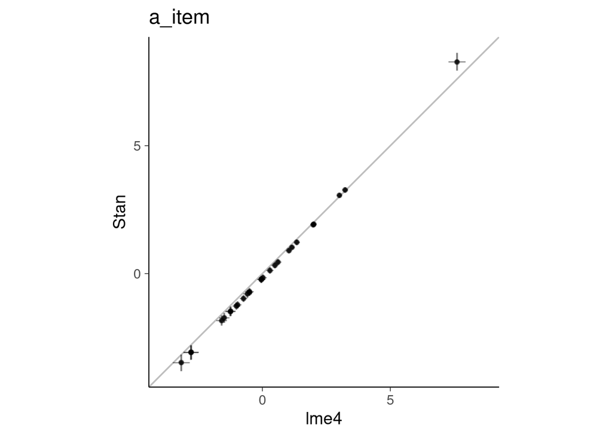

Figure 9

```r
dr4 <- fit_4$draws() |> as_draws_rvars()
a_item_hat <- ranef(fit_lme4)$item
a_item_sd <- sqrt(as.numeric(attr(a_item_hat, "postVar")))
a_item_h <- as.numeric(a_item_hat$`(Intercept)`)
rng <- range(summarize_draws(
  dr4$a_item, ~quantile(.x, probs = c(0.05, 0.95)))[,c("5%","95%")])
ggplot(data=NULL) +
  coord_fixed(xlim = rng, ylim = rng) +
  geom_abline(color="gray") +
  stat_pointinterval(aes(x = a_item_h, ydist = dr4$a_item),
                     .width = c(0.90),
                     interval_size_range = c(0.4, 0.8),
                     alpha = 0.5) +
  geom_pointinterval(aes(y = mean(dr4$a_item), x = a_item_h,
                         xmin = a_item_h - 1.64*a_item_sd,
                         xmax = a_item_h + 1.64*a_item_sd),
                     interval_size_range = c(0.4, 0.8),
                     alpha = 0.5) +
  labs(x = "lme4", y = "Stan", title = "a_item")
```

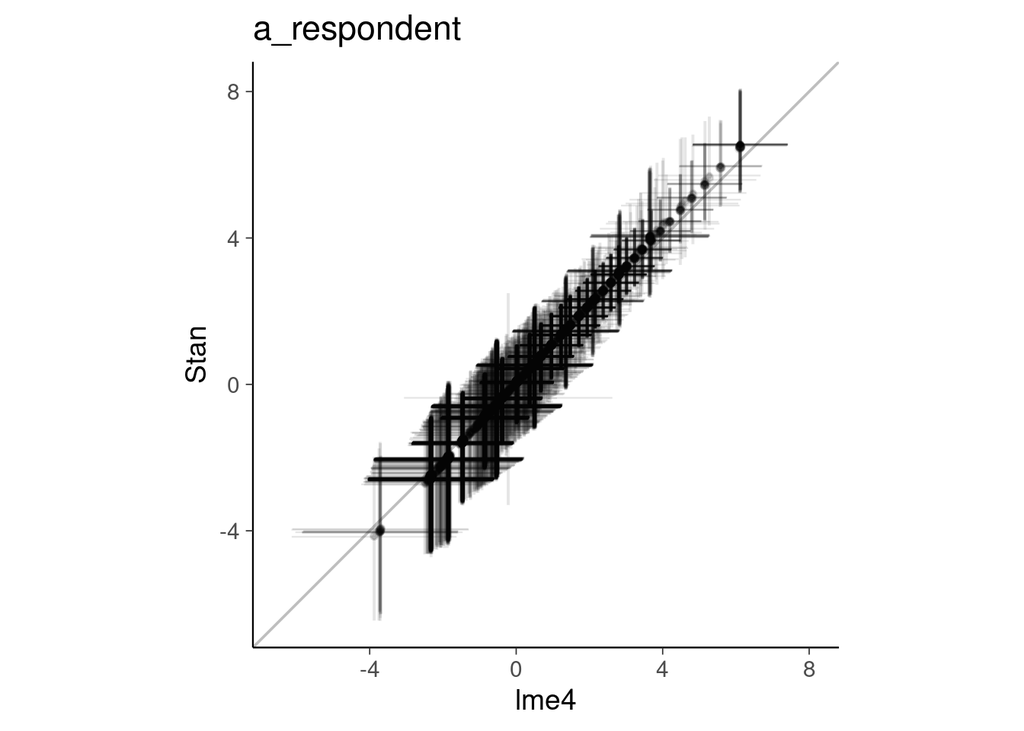

Figure 10

```r
a_respondent_hat <- ranef(fit_lme4)$respondent
a_respondent_sd <- sqrt(as.numeric(attr(a_respondent_hat, "postVar")))
a_respondent_h <- as.numeric(a_respondent_hat$`(Intercept)`)
rng <- range(summarize_draws(
  dr4$a_respondent, ~quantile(.x, probs = c(0.05, 0.95)))[,c("5%","95%")])
ggplot(data=NULL) +
  coord_fixed(xlim = rng, ylim = rng) +
  geom_abline(color="gray") +
  stat_pointinterval(aes(x = a_respondent_h, ydist = dr4$a_respondent),
                     .width = c(0.90),
                     interval_size_range = c(0.4, 0.8),
                     alpha = 0.1) +
  geom_pointinterval(aes(y = mean(dr4$a_respondent), x = a_respondent_h,
                         xmin = a_respondent_h - 1.64*a_respondent_sd,
                         xmax = a_respondent_h + 1.64*a_respondent_sd),
                     interval_size_range = c(0.4, 0.8),
                     alpha = 0.1) +
  labs(x = "lme4", y = "Stan", title = "a_respondent")
```

There is not much difference, although Stan estimates have slightly wider range. For most purposes lme4 result would be just fine and computationally faster than full Bayes for this kind of big data.

The wider range of Stan estimates is likely due to effect of integrating over the uncertainty in `sigma_item` and `sigma_respondent`:

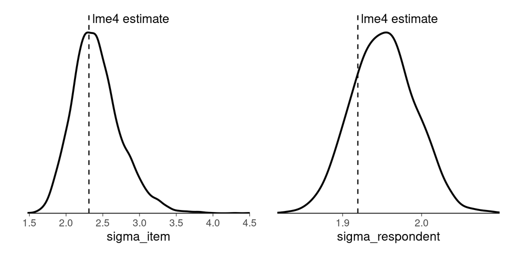

Figure 11

```r
ggplot(data=NULL) +
  stat_slab(aes(xdist = dr4$sigma_item), density = "unbounded", trim = TRUE, fill = NA, color = "black") +
  scale_y_continuous(breaks = NULL) +
  theme(axis.line.y = element_blank(), strip.text.y = element_blank()) +
  coord_cartesian(expand = FALSE) +
  ## xlim(c(0.005, 0.025)) +
  labs(x = "sigma_item", y = "") +
  geom_vline(xintercept = as.data.frame(VarCorr(fit_lme4))$sdcor[2], color = "black", linetype="dashed")+
  annotate(geom = "text", x = as.data.frame(VarCorr(fit_lme4))$sdcor[2]*1.02, y = .97, hjust=0, label = "lme4 estimate") +
ggplot(data=NULL) +
  stat_slab(aes(xdist = dr4$sigma_respondent), density = "unbounded", trim = TRUE, fill = NA, color = "black") +
  scale_y_continuous(breaks = NULL) +
  theme(axis.line.y = element_blank(), strip.text.y = element_blank()) +
  coord_cartesian(expand = FALSE) +
  ## xlim(c(0.005, 0.025)) +
  labs(x = "sigma_respondent", y = "") +
  geom_vline(xintercept = as.data.frame(VarCorr(fit_lme4))$sdcor[1], color = "black", linetype="dashed") +
  annotate(geom = "text", x = as.data.frame(VarCorr(fit_lme4))$sdcor[1]*1.002, y = .97, hjust=0, label = "lme4 estimate")
```

# References

Hart, H. L. A. 1958. “Positivism and the Separation of Law and Morals.” *Harvard Law Review* 71: 593–607.

Luu, D. 2024. “Why It’s Impossible to Agree on What’s Allowed.”

Schlag, P. 1999. “No Vehicles in the Park.” *Seattle University Law Review* 23: 381–89.

Turner, D. 2024. “No Vehicles in the Park.”

# Licenses

- Code © 2025–2026, Andrew Gelman and Aki Vehtari, licensed under BSD-3.
- Text © 2025–2026, Andrew Gelman and Aki Vehtari, licensed under CC-BY-NC 4.0.